# Step 6 — Cluster Marker Visualization

Jackson & Fischer et al. (2020) Breast Cancer | imcdatasets

Author

mass-cytometry-explorations

Published

November 20, 2026

## 1 Overview

This notebook loads the annotated object from Step 5 and compares marker expression across the PCA-space clusters. Cluster-versus-rest marker scores are used to select candidate markers for feature plots, violin plots, dot plots, and heatmaps. These rankings are descriptive: they support biological review but do not replace validation against known marker combinations and tissue context.

Inputs from Step 5:

- `results/sce_clustered_annotated.rds`

Outputs from this notebook:

- `results/marker_visualization_summary/cluster_marker_scores.csv`
- `results/marker_visualization_summary/cluster_mean_expression.csv`
- `results/marker_visualization_summary/selected_markers.csv`
- `figures/06_marker_visualization/`

## 2 Setup

```r
# Use the same plotting and path conventions as the earlier notebooks.
suppressPackageStartupMessages({
  library(SingleCellExperiment)
  library(ggplot2)
})

if (basename(getwd()) == "notebooks") {
  notebooks_dir <- normalizePath(getwd())
} else if (dir.exists(file.path(getwd(), "notebooks"))) {
  notebooks_dir <- normalizePath(file.path(getwd(), "notebooks"))
} else {
  stop("Run from project root or notebooks/ directory.")
}

if (!identical(normalizePath(getwd()), notebooks_dir)) {
  setwd(notebooks_dir)
}

summary_dir <- file.path("..", "results", "marker_visualization_summary")
figure_dir <- file.path("..", "figures", "06_marker_visualization")
dir.create(summary_dir, recursive = TRUE, showWarnings = FALSE)
dir.create(figure_dir, recursive = TRUE, showWarnings = FALSE)
cat("Working directory:", getwd(), "\n")
```

```
Working directory: /home/lizalfos/mass-cytometry-explorations/notebooks
```

## 3 Load the Step 5 object

```r
sce_path <- file.path("..", "results", "sce_clustered_annotated.rds")
if (!file.exists(sce_path)) {
  stop("Missing results/sce_clustered_annotated.rds. Please render notebooks/05_clustering_and_annotation.qmd first.")
}

sce_markers <- readRDS(sce_path)
if (!"cluster_id" %in% names(colData(sce_markers))) {
  stop("The Step 5 object does not contain colData$cluster_id.")
}

cluster_id <- droplevels(factor(colData(sce_markers)$cluster_id))
if (anyNA(cluster_id)) {
  stop("cluster_id contains missing values.")
}
cluster_levels <- levels(cluster_id)

if (!"UMAP" %in% reducedDimNames(sce_markers)) {
  stop("The Step 5 object does not contain a UMAP embedding required for feature plots.")
}
umap_embedding <- reducedDim(sce_markers, "UMAP")
if (ncol(umap_embedding) < 2L || any(!is.finite(umap_embedding[, 1:2]))) {
  stop("The UMAP embedding must contain two finite dimensions.")
}

# Reuse the assay selected by preprocessing and Step 5 when possible.
analysis_assay <- metadata(sce_markers)$preprocessing$analysis_assay
if (is.null(analysis_assay) || length(analysis_assay) != 1L ||
    !analysis_assay %in% assayNames(sce_markers)) {
  assay_candidates <- c("exprs", "quant_norm", "counts", "scaled")
  available_candidates <- assay_candidates[assay_candidates %in% assayNames(sce_markers)]
  if (length(available_candidates) == 0L) {
    stop("No supported expression assay is available.")
  }
  analysis_assay <- available_candidates[1]
}

expression_matrix <- assay(sce_markers, analysis_assay)
if (nrow(expression_matrix) != nrow(sce_markers) ||
    ncol(expression_matrix) != ncol(sce_markers)) {
  stop("The selected assay does not match the dimensions of the SCE.")
}
if (any(!is.finite(expression_matrix))) {
  stop("The selected assay contains non-finite values.")
}

cat("Cells:", ncol(sce_markers), "\n")
```

```
Cells: 272975
```

```r
cat("Markers:", nrow(sce_markers), "\n")
```

```
Markers: 42
```

```r
cat("Clusters:", length(cluster_levels), "\n")
```

```
Clusters: 20
```

```r
cat("Expression assay:", analysis_assay, "\n")
```

```
Expression assay: exprs
```

## 4 Configure marker selection

The ranking uses the difference between the mean expression in a cluster and the mean expression in all other cells. Detection percentages are retained alongside the score so that markers expressed in only a small fraction of a cluster can be distinguished from broadly informative markers.

```r
top_markers_per_cluster <- 5L
top_markers_for_dotplot <- 20L
top_markers_for_heatmap <- 20L
top_markers_for_violin <- 8L
top_markers_for_feature <- 6L

max_cells_per_cluster_for_cell_plots <- 500L
if (any(c(top_markers_per_cluster, top_markers_for_dotplot,
         top_markers_for_heatmap, top_markers_for_violin,
         top_markers_for_feature) < 1L)) {
  stop("All marker selection limits must be positive.")
}
```

## 5 Rank candidate markers by cluster

```r
marker_names <- rownames(sce_markers)
cluster_mean_matrix <- vapply(
  cluster_levels,
  function(current_cluster) {
    rowMeans(expression_matrix[, cluster_id == current_cluster, drop = FALSE])
  },
  numeric(nrow(sce_markers))
)
rownames(cluster_mean_matrix) <- marker_names
colnames(cluster_mean_matrix) <- cluster_levels

cluster_marker_scores <- do.call(
  rbind,
  lapply(cluster_levels, function(current_cluster) {
    in_cluster <- cluster_id == current_cluster
    out_cluster <- !in_cluster
    mean_in <- rowMeans(expression_matrix[, in_cluster, drop = FALSE])
    mean_out <- rowMeans(expression_matrix[, out_cluster, drop = FALSE])
    pct_in <- rowMeans(expression_matrix[, in_cluster, drop = FALSE] > 0) * 100
    pct_out <- rowMeans(expression_matrix[, out_cluster, drop = FALSE] > 0) * 100

    data.frame(
      cluster_id = current_cluster,
      marker = marker_names,
      mean_in = as.numeric(mean_in),
      mean_out = as.numeric(mean_out),
      mean_difference = as.numeric(mean_in - mean_out),
      pct_in = as.numeric(pct_in),
      pct_out = as.numeric(pct_out),
      detection_difference = as.numeric(pct_in - pct_out),
      stringsAsFactors = FALSE
    )
  })
)

cluster_marker_scores <- cluster_marker_scores[
  order(cluster_marker_scores$cluster_id,
        -cluster_marker_scores$mean_difference,
        -cluster_marker_scores$detection_difference),
]

selected_by_cluster <- do.call(
  rbind,
  lapply(cluster_levels, function(current_cluster) {
    head(
      cluster_marker_scores[
        cluster_marker_scores$cluster_id == current_cluster,
      ],
      top_markers_per_cluster
    )
  })
)
selected_markers <- unique(selected_by_cluster$marker)

write.csv(
  cluster_marker_scores,
  file.path(summary_dir, "cluster_marker_scores.csv"),
  row.names = FALSE
)
write.csv(
  data.frame(marker = rownames(cluster_mean_matrix),
             cluster_mean_matrix,
             check.names = FALSE),
  file.path(summary_dir, "cluster_mean_expression.csv"),
  row.names = FALSE
)
write.csv(
  selected_by_cluster,
  file.path(summary_dir, "selected_markers.csv"),
  row.names = FALSE
)

head(selected_by_cluster)
```

```
   cluster_id marker  mean_in  mean_out mean_difference pct_in   pct_out
5  Cluster_01   CDH1 2.725904 1.5371789       1.1887249    100  99.99308
8  Cluster_01     H3 3.567973 2.3908414       1.1771319    100 100.00000
13 Cluster_01  GATA3 1.606768 0.5473657       1.0594025    100  99.01128
1  Cluster_01  PanCK 2.999461 1.9406739       1.0587868    100  99.23587
9  Cluster_01   HER2 1.950921 1.0154900       0.9354308    100  99.98000
48 Cluster_02   CD44 4.473093 3.3848936       1.0881990    100 100.00000
   detection_difference
5           0.006922172
8           0.000000000
13          0.988716860
1           0.764130844
9           0.019997385
48          0.000000000
```

## 6 Feature plots

Feature plots show the spatial distribution of selected markers on the UMAP embedding. A balanced sample of cells from each cluster keeps the rendered HTML responsive without changing the marker rankings.

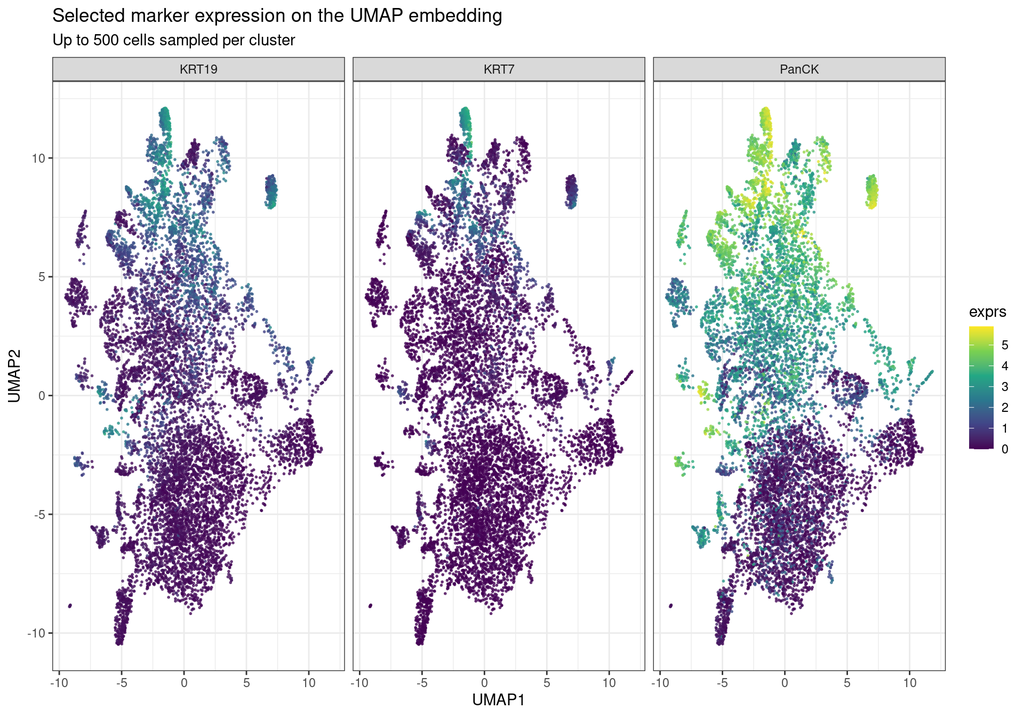

```r
set.seed(2026L)
plot_cells <- unlist(lapply(cluster_levels, function(current_cluster) {
  cells <- which(cluster_id == current_cluster)
  sample(cells, min(length(cells), max_cells_per_cluster_for_cell_plots))
}), use.names = FALSE)

feature_markers <- unique(head(
  selected_by_cluster[order(-selected_by_cluster$mean_difference), ]$marker,
  top_markers_for_feature
))
feature_plot_data <- data.frame(
  UMAP1 = umap_embedding[plot_cells, 1],
  UMAP2 = umap_embedding[plot_cells, 2],
  cluster_id = cluster_id[plot_cells],
  t(expression_matrix[feature_markers, plot_cells, drop = FALSE]),
  check.names = FALSE
)

feature_long <- do.call(
  rbind,
  lapply(feature_markers, function(marker) {
    data.frame(
      UMAP1 = feature_plot_data$UMAP1,
      UMAP2 = feature_plot_data$UMAP2,
      marker = marker,
      expression = feature_plot_data[[marker]],
      stringsAsFactors = FALSE
    )
  })
)

ggplot(feature_long, aes(UMAP1, UMAP2, colour = expression)) +
  geom_point(size = 0.35, alpha = 0.7) +
  facet_wrap(~marker, ncol = 3) +
  scale_colour_viridis_c() +
  labs(
    title = "Selected marker expression on the UMAP embedding",
    subtitle = sprintf("Up to %d cells sampled per cluster", max_cells_per_cluster_for_cell_plots),
    colour = analysis_assay,
    x = "UMAP1",
    y = "UMAP2"
  ) +
  theme_bw()
```

## 7 Violin plots

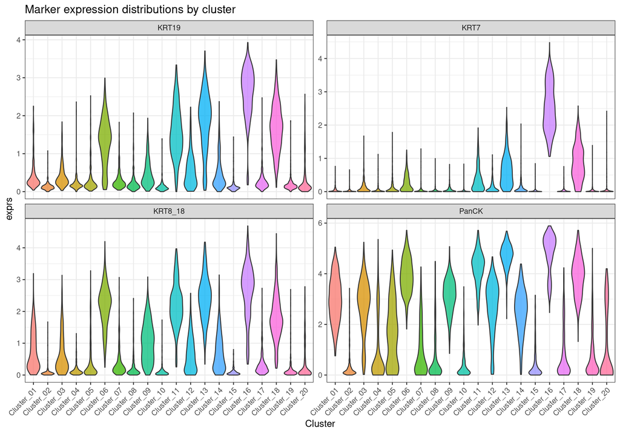

```r
violin_markers <- unique(head(
  selected_by_cluster[order(-selected_by_cluster$mean_difference), ]$marker,
  top_markers_for_violin
))
violin_data <- data.frame(
  cluster_id = cluster_id[plot_cells],
  t(expression_matrix[violin_markers, plot_cells, drop = FALSE]),
  check.names = FALSE
)
violin_long <- do.call(
  rbind,
  lapply(violin_markers, function(marker) {
    data.frame(
      cluster_id = violin_data$cluster_id,
      marker = marker,
      expression = violin_data[[marker]],
      stringsAsFactors = FALSE
    )
  })
)

ggplot(violin_long, aes(cluster_id, expression, fill = cluster_id)) +
  geom_violin(scale = "width", trim = TRUE, alpha = 0.75) +
  facet_wrap(~marker, scales = "free_y", ncol = 2) +
  labs(
    title = "Marker expression distributions by cluster",
    x = "Cluster",
    y = analysis_assay
  ) +
  theme_bw() +
  theme(
    legend.position = "none",
    axis.text.x = element_text(angle = 45, hjust = 1)
  )
```

## 8 Dot plot

Dot size shows the percentage of cells with positive expression, while colour shows the mean expression within each cluster.

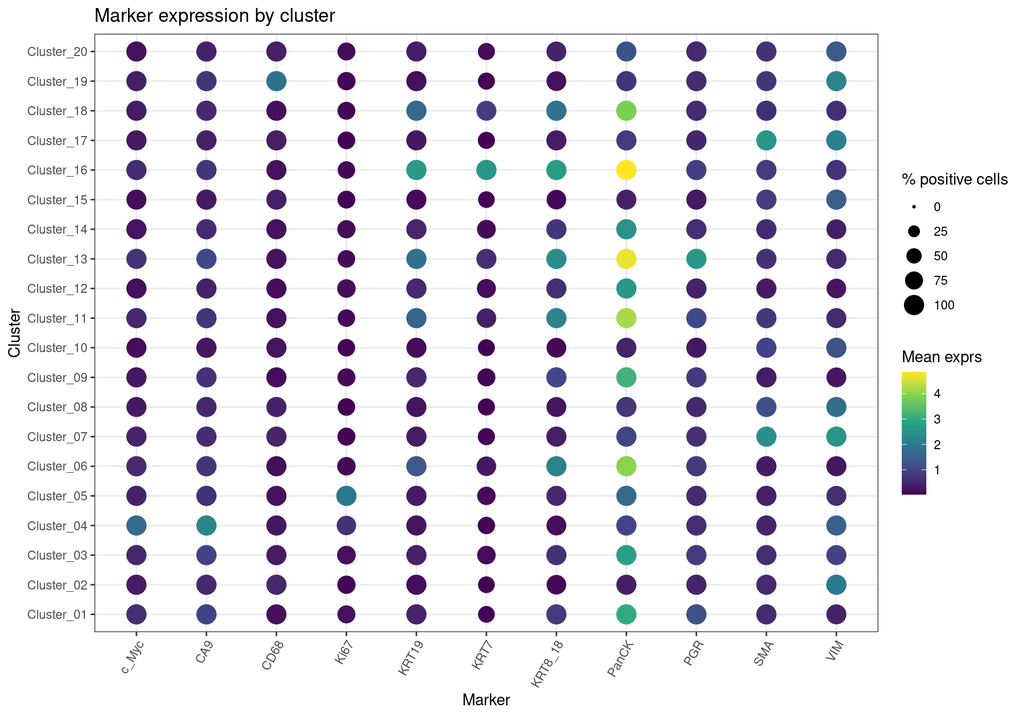

```r
dot_markers <- unique(head(
  selected_by_cluster[order(-selected_by_cluster$mean_difference), ]$marker,
  top_markers_for_dotplot
))
dot_data <- do.call(
  rbind,
  lapply(cluster_levels, function(current_cluster) {
    cells <- cluster_id == current_cluster
    data.frame(
      cluster_id = current_cluster,
      marker = dot_markers,
      mean_expression = rowMeans(expression_matrix[dot_markers, cells, drop = FALSE]),
      percent_positive = rowMeans(expression_matrix[dot_markers, cells, drop = FALSE] > 0) * 100,
      stringsAsFactors = FALSE
    )
  })
)

ggplot(dot_data, aes(marker, cluster_id)) +
  geom_point(aes(size = percent_positive, colour = mean_expression)) +
  scale_colour_viridis_c() +
  scale_size(range = c(0.5, 6), limits = c(0, 100)) +
  labs(
    title = "Marker expression by cluster",
    x = "Marker",
    y = "Cluster",
    colour = paste("Mean", analysis_assay),
    size = "% positive cells"
  ) +
  theme_bw() +
  theme(axis.text.x = element_text(angle = 60, hjust = 1))
```

## 9 Heatmaps

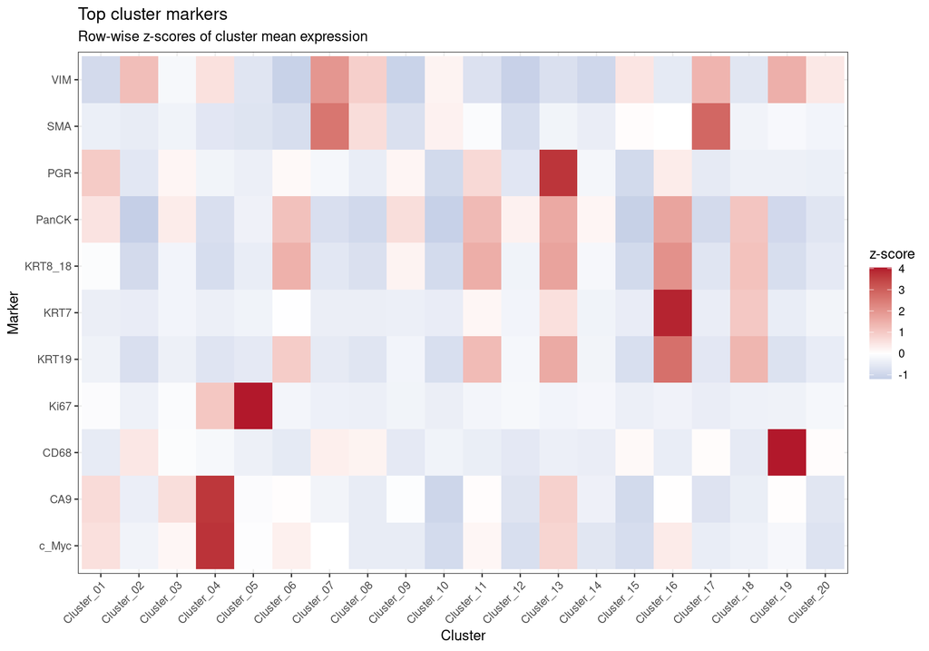

```r
heatmap_markers <- unique(head(
  selected_by_cluster[order(-selected_by_cluster$mean_difference), ]$marker,
  top_markers_for_heatmap
))
heatmap_matrix <- cluster_mean_matrix[heatmap_markers, , drop = FALSE]
heatmap_z <- t(scale(t(heatmap_matrix)))
heatmap_z[!is.finite(heatmap_z)] <- 0

heatmap_data <- expand.grid(
  marker = rownames(heatmap_z),
  cluster_id = colnames(heatmap_z),
  stringsAsFactors = FALSE
)
heatmap_data$z_score <- as.vector(heatmap_z)

ggplot(heatmap_data, aes(cluster_id, marker, fill = z_score)) +
  geom_tile() +
  scale_fill_gradient2(low = "#2166ac", mid = "white", high = "#b2182b") +
  labs(
    title = "Top cluster markers",
    subtitle = "Row-wise z-scores of cluster mean expression",
    x = "Cluster",
    y = "Marker",
    fill = "z-score"
  ) +
  theme_bw() +
  theme(axis.text.x = element_text(angle = 45, hjust = 1))
```

## 10 Marker ranking per cluster

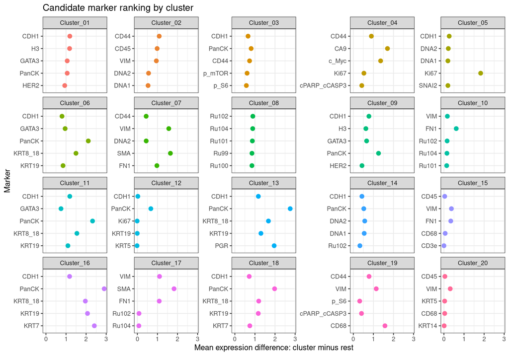

```r
ranking_plot_data <- selected_by_cluster
ranking_plot_data$marker <- factor(
  ranking_plot_data$marker,
  levels = rev(unique(ranking_plot_data$marker))
)

ggplot(ranking_plot_data,
       aes(x = mean_difference, y = marker, colour = cluster_id)) +
  geom_point(size = 2.5) +
  facet_wrap(~cluster_id, scales = "free_y") +
  labs(
    title = "Candidate marker ranking by cluster",
    x = "Mean expression difference: cluster minus rest",
    y = "Marker",
    colour = "Cluster"
  ) +
  theme_bw() +
  theme(legend.position = "none")
```

**TipInterpretation**

Use the exported `cluster_marker_scores.csv` together with the feature, violin, dot, and heatmap views. A useful candidate marker is usually supported by a large cluster-versus-rest difference, high within-cluster detection, and a coherent combination with other markers. Treat isolated high values or low-frequency signals as hypotheses for review rather than confirmed cell types.